# Faza2

Ewelina Karbowiak i Wioleta Stojak

11 listopada 2016

# Wstęp

Aby wybrać model najlepiej stosujący się do naszych danych, przetestowane zostały różne podejścia, zarówno liniowe jak i nieliniowe.

Użyte modelele:

*pełny model liniowy lm

*uogólniony model liniowy glm

*powyższe modele z wykorzystaniem kryterium AIC

*powyższe modele z wykorzystaniem kryterium BIC

*drzewo decyzyjne z wykorzystaniem funckji rpart

*Naive Bayes

*las losowy

Modele przetestowałyśmy w oparciu o bład średniokwadratowy (MSE), tabele kontygencji powtarzając losowanie zbioru uczącego (1:3) 100 razy oraz 10-fold CV z powtorzeniem 10 krotnym. Wykonałysmy również krzywe ROC do pojedyńczych losowań i porównałysmy pola pod wykresami w każdej z metod.

# Użyte modele

## Pełny model liniowy lm

Na początku postanowiłyśmy wypróbować zwykły model liniowy

```r
ROC<-numeric(9)
names(ROC)<-c("lm","glm","lm.AIC","glm.AIC","lm.BIC","glm.BIC","DRZEWO","NB","RF")
#pojedyncze losowanie 1:3
indeksy<-c()
set.seed(33)
indeksy<-unlist(createDataPartition(dane$death1y, times=1, p = 0.75))

model_LM<-lm(smierc~.,data=na.omit(dane[indeksy,-2]))
summary.lm(model_LM)
```

```
##
## Call:
## lm(formula = smierc ~ ., data = na.omit(dane[indeksy, -2]))
##
## Residuals:
##      Min       1Q   Median       3Q      Max
## -0.75701 -0.27237 -0.06674  0.31354  0.91612
##
## Coefficients:
##              Estimate Std. Error t value Pr(>|t|)
## (Intercept)  0.960502   0.537192   1.788   0.0787 .
## age         -0.007637   0.004630  -1.650   0.1041
## CTPS2       -0.021433   0.201909  -0.106   0.9158
## IDO1        -0.012856   0.025886  -0.497   0.6212
## IFI44        0.093409   0.075777   1.233   0.2223
## LRRC57      -0.121860   0.177549  -0.686   0.4951
## MAP1S        0.013599   0.190795   0.071   0.9434
## MYBBP1A     -0.231555   0.202597  -1.143   0.2575
## SLC10A3     -0.018039   0.176262  -0.102   0.9188
## SLC35B1     -0.310506   0.243144  -1.277   0.2063
## SOAT1        0.030291   0.183042   0.165   0.8691
## STAC         0.013453   0.035519   0.379   0.7062
## STAT6       -0.085102   0.139109  -0.612   0.5429
## THAP6       -0.222003   0.240045  -0.925   0.3586
## BCL2L13      0.017734   0.230406   0.077   0.9389
## CLEC3B      -0.031911   0.050372  -0.634   0.5287
## IFI27L2     -0.291015   0.123694  -2.353   0.0218 *
## IL20RB       0.144873   0.079324   1.826   0.0726 .
## LSM5        -0.021858   0.165079  -0.132   0.8951
## MYO1C        0.137466   0.207075   0.664   0.5092
## OSGEPL1      0.323302   0.277808   1.164   0.2490
## PVRIG       -0.106445   0.074212  -1.434   0.1565
## HIVEP3      -0.043936   0.108229  -0.406   0.6862
## PLAGL1      -0.054787   0.063495  -0.863   0.3915
## SLC16A11    -0.005820   0.049156  -0.118   0.9061
## SLC16A8      0.013642   0.054879   0.249   0.8045
## MXD1        -0.161406   0.113590  -1.421   0.1603
## ---
## Signif. codes:  0 '***' 0.001 '**' 0.01 '*' 0.05 '.' 0.1 ' ' 1
##
## Residual standard error: 0.474 on 62 degrees of freedom
## Multiple R-squared:  0.3732, Adjusted R-squared:  0.1103
## F-statistic:  1.42 on 26 and 62 DF,  p-value: 0.1309
```

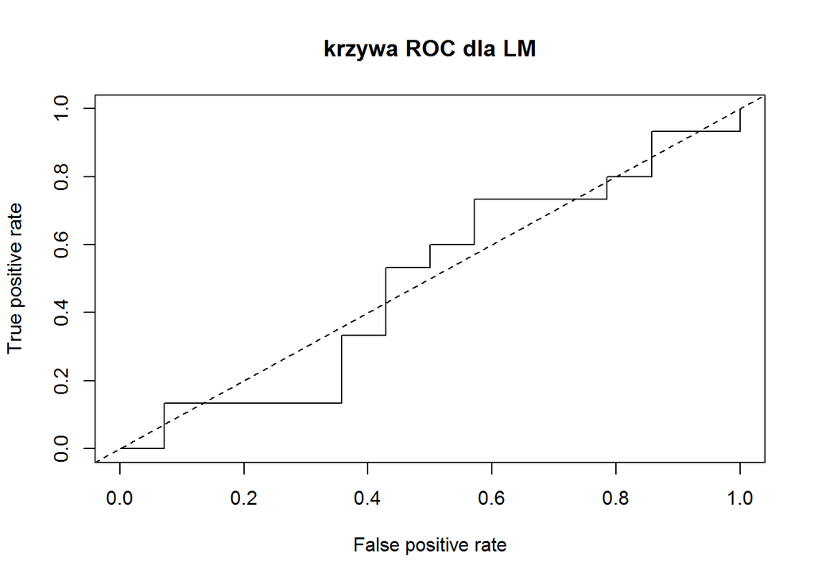

```r
predy_LM<-predict(model_LM,newdata=dane[-indeksy,-2])
mse.LM<-mse(predy_LM,dane[-indeksy,"smierc"])

#krzywa ROC
p<-prediction(predy_LM,dane[-indeksy,"smierc"])
plot(performance(p, "tpr", "fpr"),main = "krzywa ROC dla LM")
abline(0, 1, lty = 2)
```

```r
ROC[1]<-roc(dane[-indeksy,"smierc"], predy_LM)$auc

#sto razy powtorzony mse dla lm 1:3
Tk.lm <- rbind(c(0,0),c(0,0))
LM<-replicate(100,{
  indeksy<-c()
  indeksy<-unlist(createDataPartition(dane$death1y, times=1, p = 0.75))
  model_LM<-lm(smierc~.,data=na.omit(dane[indeksy,-2]))
  predy_LM<-predict(model_LM,newdata=dane[-indeksy,-2])
  a <- confusion.matrix(dane[-indeksy,"smierc"],predy_LM,threshold=0.5)
  Tk.lm <<- mapply(sum,Tk.lm,a)
  mse(predy_LM,dane[-indeksy,"smierc"])
})

#sto razy łacznie 10x10 mse dla lm z cv-fold
LMCV<-replicate(10,{
  jak<-createFolds(dane$smierc,k=10)
  error<-lapply(jak,function(ind) {
    model_LM<-lm(smierc~.,data=dane[-ind,-2])
    predy_LM<-predict.lm(model_LM,newdata = dane[ind,-2])
    mse(predy_LM,dane[ind,"smierc"])

  })
})
```

## Uogólniony model liniowy glm

```r
model_GLM<-glm(smierc~.,data=na.omit(dane[indeksy,-2]),family = "binomial")
summary.glm(model_GLM)
```

```
##
## Call:
## glm(formula = smierc ~ ., family = "binomial", data = na.omit(dane[indeksy,
##     -2]))
##
## Deviance Residuals:
##     Min       1Q   Median       3Q      Max
## -2.0263  -0.7336  -0.1008   0.7517   2.3679
##
## Coefficients:
##              Estimate Std. Error z value Pr(>|z|)
## (Intercept)  2.433624   2.892517   0.841   0.4002
## age         -0.060884   0.029290  -2.079   0.0376 *
## CTPS2       -0.347770   1.042094  -0.334   0.7386
## IDO1        -0.087887   0.145537  -0.604   0.5459
## IFI44        0.522803   0.430644   1.214   0.2247
## LRRC57      -0.769482   1.037123  -0.742   0.4581
## MAP1S        0.412981   1.102793   0.374   0.7080
## MYBBP1A     -1.466154   1.181243  -1.241   0.2145
## SLC10A3     -0.449522   0.962015  -0.467   0.6403
## SLC35B1     -2.270352   1.440524  -1.576   0.1150
## SOAT1        1.244701   1.162681   1.071   0.2844
## STAC         0.086634   0.213420   0.406   0.6848
## STAT6       -1.049746   0.818671  -1.282   0.1998
## THAP6       -1.237558   1.356358  -0.912   0.3616
## BCL2L13      0.267012   1.290798   0.207   0.8361
## CLEC3B      -0.200861   0.293204  -0.685   0.4933
## IFI27L2     -1.703702   0.715789  -2.380   0.0173 *
## IL20RB       0.937809   0.469128   1.999   0.0456 *
## LSM5        -0.223605   0.898317  -0.249   0.8034
## MYO1C        1.322004   1.188491   1.112   0.2660
## OSGEPL1      2.853667   1.708895   1.670   0.0949 .
## PVRIG       -0.553928   0.396214  -1.398   0.1621
## HIVEP3      -0.522770   0.646004  -0.809   0.4184
## PLAGL1      -0.458766   0.398897  -1.150   0.2501
## SLC16A11     0.002479   0.263471   0.009   0.9925
## SLC16A8      0.062064   0.309938   0.200   0.8413
## MXD1        -1.217244   0.755701  -1.611   0.1072
## ---
## Signif. codes:  0 '***' 0.001 '**' 0.01 '*' 0.05 '.' 0.1 ' ' 1
##
## (Dispersion parameter for binomial family taken to be 1)
##
##     Null deviance: 123.279  on 88  degrees of freedom
## Residual deviance:  81.151  on 62  degrees of freedom
## AIC: 135.15
##
## Number of Fisher Scoring iterations: 5
```

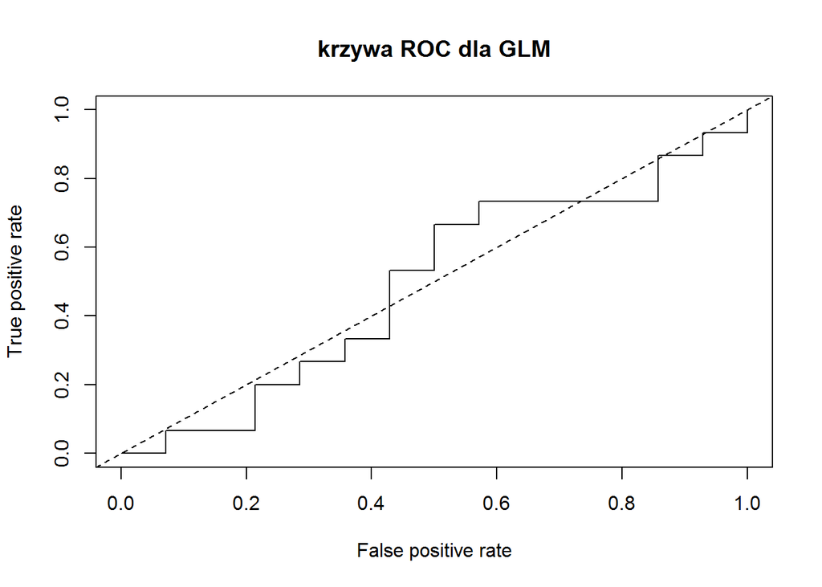

```r
predy_GLM<-predict.glm(model_GLM,newdata=dane[-indeksy,-2],type = "response")
mse.GLM<-mse(predy_GLM,dane[-indeksy,"smierc"])
#KRZYWA ROC
p<-prediction(predy_GLM,dane[-indeksy,"smierc"])
plot(performance(p, "tpr", "fpr"),main = "krzywa ROC dla GLM")

abline(0, 1, lty = 2)
```

```r
ROC[2]<-roc(dane[-indeksy,"smierc"], predy_GLM)$auc

#sto razy mse dla glm 1:3
Tk.glm <- rbind(c(0,0),c(0,0))
GLM<-replicate(100,{
  indeksy<-c()
  indeksy<-unlist(createDataPartition(dane$death1y, times=1, p = 0.75))
  model_GLM<-glm(smierc~.,data=na.omit(dane[indeksy,-2]),family="binomial")
  predy_GLM<-predict(model_GLM,newdata=dane[-indeksy,-2],type = "response")
  a<-confusion.matrix(dane[-indeksy,"smierc"],predy_GLM,threshold=0.5)
  Tk.glm <<- mapply(sum,Tk.glm,a)
  mse(predy_GLM,dane[-indeksy,"smierc"])
})

#łacznie 100 razy mse dla glm cv-fold
GLMCV<-replicate(10,{
  jak<-createFolds(dane$smierc,k=10)
  error<-lapply(jak,function(ind) {
    model_GLM<-glm(smierc~.,data=dane[-ind,-2],family = "binomial")
    predy_GLM<-predict(model_GLM,newdata = dane[ind,-2],type = "response")
    mse(predy_GLM,dane[ind,"smierc"])  })
})
```

## Optymalne modele według kryterium AIC

Aby ograniczyć liczbę parametrów, użyłyśmy kryterium AIC.

```r
optimalAICLM <- step(model_LM,direction="backward",trace=FALSE)
summary.lm(optimalAICLM)
```

```
##
## Call:
## lm(formula = smierc ~ age + IFI44 + SLC35B1 + THAP6 + IFI27L2 +
##     IL20RB + OSGEPL1 + PVRIG + MXD1, data = na.omit(dane[indeksy,
##     -2]))
##
## Residuals:
##      Min       1Q   Median       3Q      Max
## -0.80882 -0.34527  0.00006  0.35436  0.98467
##
## Coefficients:
##              Estimate Std. Error t value Pr(>|t|)
## (Intercept)  1.017064   0.268969   3.781 0.000302 ***
## age         -0.006691   0.003639  -1.839 0.069700 .
## IFI44        0.086438   0.060733   1.423 0.158601
## SLC35B1     -0.353726   0.177218  -1.996 0.049380 *
## THAP6       -0.242624   0.159972  -1.517 0.133343
## IFI27L2     -0.271135   0.079395  -3.415 0.001010 **
## IL20RB       0.135095   0.060355   2.238 0.028015 *
## OSGEPL1      0.363583   0.147620   2.463 0.015954 *
## PVRIG       -0.140941   0.049723  -2.835 0.005824 **
## MXD1        -0.127439   0.085734  -1.486 0.141142
## ---
## Signif. codes:  0 '***' 0.001 '**' 0.01 '*' 0.05 '.' 0.1 ' ' 1
##
## Residual standard error: 0.4367 on 79 degrees of freedom
## Multiple R-squared:  0.3222, Adjusted R-squared:  0.245
## F-statistic: 4.172 on 9 and 79 DF,  p-value: 0.0001974
```

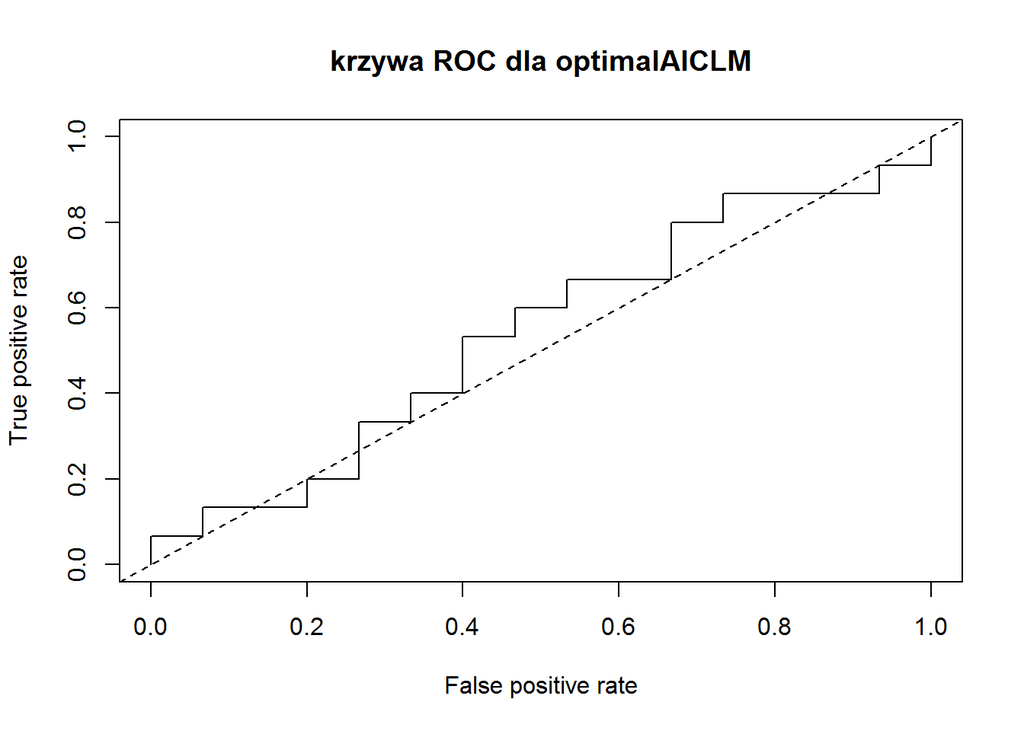

```r
predy.optimalAICLM<-predict(optimalAICLM,newdata=dane[-indeksy,-2])
mse.optimalAICLM<-mse(predy.optimalAICLM,dane[-indeksy,"smierc"])

p<-prediction(predy.optimalAICLM,dane[-indeksy,"smierc"])
plot(performance(p, "tpr", "fpr"),main = "krzywa ROC dla optimalAICLM")
abline(0, 1, lty = 2)
```

```r
ROC[3]<-roc(dane[-indeksy,"smierc"], predy.optimalAICLM)$auc

#STO RAZY mse dla OptAICLM 1:3 dodaje trace=false by sie wyniki nie wyswietlały w trakcie
Tk.AIClm <- rbind(c(0,0),c(0,0))
OPAICLM<-replicate(100,{
  indeksy<-c()
  indeksy<-unlist(createDataPartition(dane$death1y, times=1, p = 0.75))
  model_LM<-lm(smierc~.,data=na.omit(dane[indeksy,-2]))
  optimalAICLM<-step(model_LM,direction = "backward",trace = FALSE,k=2)
  predy.opTimalAICLM<-predict(optimalAICLM,newdata=dane[-indeksy,-2])
  a<-confusion.matrix(dane[-indeksy,"smierc"],predy.optimalAICLM,threshold=0.5)
  Tk.AIClm<<-mapply(sum,Tk.AIClm,a)
  mse(predy.optimalAICLM,dane[-indeksy,"smierc"])
})

#sto razy mse dla optAICLM CV FOLD
OPAICLMCV<-replicate(10,{
  jak<-createFolds(dane$smierc,k=10)
  error<-lapply(jak,function(ind) {
    model_LM<-lm(smierc~.,data=na.omit(dane[-ind,-2]))
    optimalAICLM<-step(model_LM,direction = "backward",trace = FALSE,k=2)
    predy.optimalAICLM<-predict(optimalAICLM,newdata=dane[ind,-2])
    mse(predy.optimalAICLM,dane[ind,"smierc"])
  })
})
```

```r
optimalAICGLM <- step(model_GLM,direction="backward",k=2,trace=FALSE)
summary.glm(optimalAICGLM)
```

```
##
## Call:
## glm(formula = smierc ~ age + IFI44 + SLC35B1 + THAP6 + IFI27L2 +
##     IL20RB + OSGEPL1 + PVRIG + MXD1, family = "binomial", data = na.omit(dane[indeksy,
##     -2]))
##
## Deviance Residuals:
##     Min       1Q   Median       3Q      Max
## -2.0484  -0.8346  -0.2943   0.8380   2.3857
##
## Coefficients:
##             Estimate Std. Error z value Pr(>|z|)
## (Intercept)  3.19412    1.65420   1.931   0.0535 .
## age         -0.04180    0.02303  -1.815   0.0695 .
## IFI44        0.53215    0.35974   1.479   0.1391
## SLC35B1     -2.22349    1.07869  -2.061   0.0393 *
## THAP6       -1.50996    0.94333  -1.601   0.1094
## IFI27L2     -1.58484    0.50509  -3.138   0.0017 **
## IL20RB       0.79696    0.36310   2.195   0.0282 *
## OSGEPL1      2.24263    0.92858   2.415   0.0157 *
## PVRIG       -0.73018    0.30321  -2.408   0.0160 *
## MXD1        -0.71488    0.49381  -1.448   0.1477
## ---
## Signif. codes:  0 '***' 0.001 '**' 0.01 '*' 0.05 '.' 0.1 ' ' 1
##
## (Dispersion parameter for binomial family taken to be 1)
##
##     Null deviance: 123.279  on 88  degrees of freedom
## Residual deviance:  89.007  on 79  degrees of freedom
## AIC: 109.01
##
## Number of Fisher Scoring iterations: 5
```

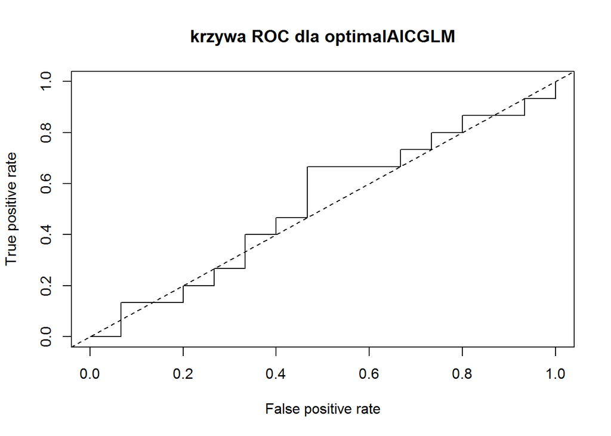

```r
predy.optimalAICGLM<-predict(optimalAICGLM,newdata=dane[-indeksy,-2],type="response")
mse.optimalAICGLM<-mse(predy.optimalAICGLM,dane[-indeksy,"smierc"])

p<-prediction(predy.optimalAICGLM,dane[-indeksy,"smierc"])
plot(performance(p, "tpr", "fpr"),main="krzywa ROC dla optimalAICGLM")
abline(0, 1, lty = 2)
```

```r
ROC[4]<-roc(dane[-indeksy,"smierc"], predy.optimalAICGLM)$auc

#100 razy MSE dla optimalAICGLM 1:3
Tk.AICglm <- rbind(c(0,0),c(0,0))
OPAICGLM<-replicate(100,{
  indeksy<-c()
  indeksy<-unlist(createDataPartition(dane$death1y, times=1, p = 0.75))
  model_GLM<-glm(smierc~.,data=na.omit(dane[indeksy,-2]),family = "binomial")
  optimalAICGLM<-step(model_GLM,direction = "backward",trace = FALSE,k=2)
  predy.opTimalAICGLM<-predict(optimalAICGLM,newdata=dane[-indeksy,-2],type="response")

  a<-confusion.matrix(dane[-indeksy,"smierc"],predy.optimalAICGLM,threshold=0.5)
  Tk.AICglm<<-mapply(sum,Tk.AICglm,a)
  mse(predy.optimalAICGLM,dane[-indeksy,"smierc"])
})

#sto razy mse dla oprimalAICGLM cv-fold
OPAICGLMCV<-replicate(10,{
  jak<-createFolds(dane$smierc,k=10)
  error<-lapply(jak,function(ind) {
    model_GLM<-glm(smierc~.,data=na.omit(dane[-ind,-2]),family="binomial")
    optimalAICGLM<-step(model_GLM,direction = "backward",trace = FALSE,k=2)
    predy.optimalAICGLM<-predict(optimalAICGLM,newdata=dane[ind,-2],type="response")
    mse(predy.optimalAICGLM,dane[ind,"smierc"])
  })
})
```

## Optymalne modele według kryterium BIC

Ponownie ograniczamy liczbę parametrów stosując kryterium BIC.

```r
optimalBICLM<-step(model_LM,direction="backward",k=log(nrow(dane[indeksy,])),trace=FALSE)
summary.lm(optimalBICLM)
```

```
##
## Call:
## lm(formula = smierc ~ age + SLC35B1 + IFI27L2 + IL20RB + OSGEPL1 +
##     PVRIG + MXD1, data = na.omit(dane[indeksy, -2]))
##
## Residuals:
##      Min       1Q   Median       3Q      Max
## -0.86223 -0.31244 -0.04181  0.36853  0.86453
##
## Coefficients:
##              Estimate Std. Error t value Pr(>|t|)
## (Intercept)  1.210810   0.245480   4.932 4.26e-06 ***
## age         -0.007709   0.003632  -2.123  0.03685 *
## SLC35B1     -0.375940   0.165712  -2.269  0.02595 *
## IFI27L2     -0.256132   0.076251  -3.359  0.00119 **
## IL20RB       0.128342   0.057556   2.230  0.02853 *
## OSGEPL1      0.314664   0.122855   2.561  0.01228 *
## PVRIG       -0.137186   0.048637  -2.821  0.00603 **
## MXD1        -0.181196   0.079956  -2.266  0.02611 *
## ---
## Signif. codes:  0 '***' 0.001 '**' 0.01 '*' 0.05 '.' 0.1 ' ' 1
##
## Residual standard error: 0.4409 on 81 degrees of freedom
## Multiple R-squared:  0.2916, Adjusted R-squared:  0.2304
## F-statistic: 4.763 on 7 and 81 DF,  p-value: 0.0001604
```

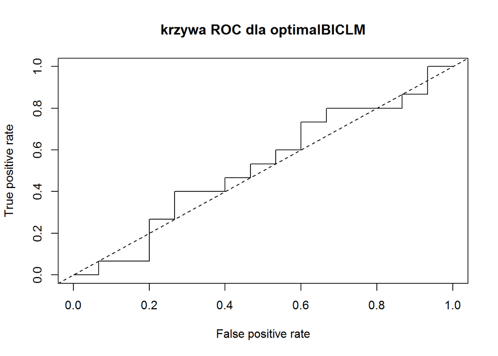

```r
predy.optimalBICLM<-predict(optimalBICLM,newdata=dane[-indeksy,-2])
mse.optimalBICLM<-mse(predy.optimalBICLM,dane[-indeksy,"smierc"])

p<-prediction(predy.optimalBICLM,dane[-indeksy,"smierc"])
plot(performance(p, "tpr", "fpr"),main="krzywa ROC dla optimalBICLM")
abline(0, 1, lty = 2)
```

```r
ROC[5]<-roc(dane[-indeksy,"smierc"], predy.optimalBICLM)$auc

#STO RAZY mse dla OptBICLM 1:3
Tk.BIClm <- rbind(c(0,0),c(0,0))
OPBICLM<-replicate(100,{
  indeksy<-c()
  indeksy<-unlist(createDataPartition(dane$death1y, times=1, p = 0.75))
  model_LM<-lm(smierc~.,data=na.omit(dane[indeksy,-2]))
  optimalBICLM<-step(model_LM,direction = "backward",trace = FALSE, k=log(nrow(dane[indeksy,])))
  predy.optimalBICLM<-predict(optimalAICLM,newdata=dane[-indeksy,-2])
  a<-confusion.matrix(dane[-indeksy,"smierc"],predy.optimalBICLM,threshold=0.5)
  Tk.BIClm<<-mapply(sum,Tk.BIClm,a)
  mse(predy.optimalBICLM,dane[-indeksy,"smierc"])
})

#sto razy mse dla optBICLM CV FOLD
OPBICLMCV<-replicate(10,{
  jak<-createFolds(dane$smierc,k=10)
  error<-lapply(jak,function(ind) {
    model_LM<-lm(smierc~.,data=na.omit(dane[-ind,-2]))
    optimalBICLM<-step(model_LM,direction =    "backward",trace=FALSE,k=2)
    predy.optimalBICLM<-predict(optimalBICLM,newdata=dane[ind,-2])
    mse(predy.optimalBICLM,dane[ind,"smierc"])
  })
})
```

```r
optimalBICGLM<-step(model_GLM,direction="backward",k=log(nrow(dane[indeksy,])),trace = FALSE)
summary.glm(optimalBICGLM)
```

```
##
## Call:
## glm(formula = smierc ~ IFI27L2 + OSGEPL1 + PVRIG, family = "binomial",
##     data = na.omit(dane[indeksy, -2]))
##
## Deviance Residuals:
##     Min       1Q   Median       3Q      Max
## -1.9579  -1.0077  -0.4797   1.0180   2.0780
##
## Coefficients:
##             Estimate Std. Error z value Pr(>|z|)
## (Intercept)   1.3495     0.6637   2.033  0.04202 *
## IFI27L2      -1.3165     0.4268  -3.084  0.00204 **
## OSGEPL1       1.3920     0.5779   2.408  0.01602 *
## PVRIG        -0.5841     0.2500  -2.337  0.01946 *
## ---
## Signif. codes:  0 '***' 0.001 '**' 0.01 '*' 0.05 '.' 0.1 ' ' 1
##
## (Dispersion parameter for binomial family taken to be 1)
##
##     Null deviance: 123.28  on 88  degrees of freedom
## Residual deviance: 107.40  on 85  degrees of freedom
## AIC: 115.4
##
## Number of Fisher Scoring iterations: 4
```

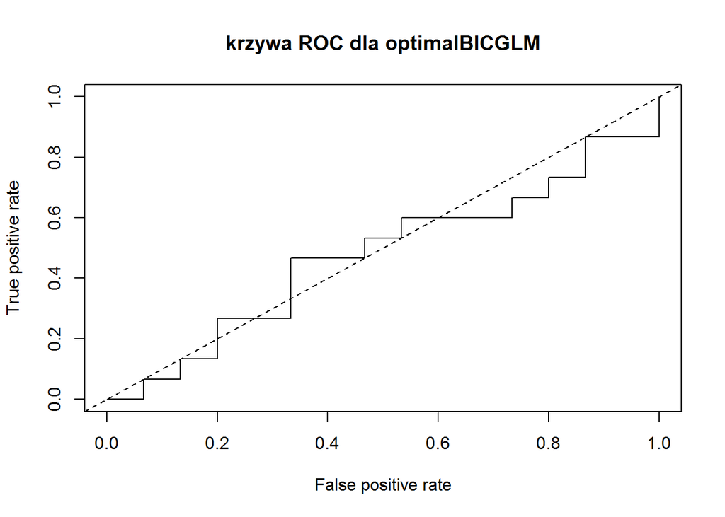

```r
predy.optimalBICGLM<-predict(optimalBICGLM,newdata=dane[-indeksy,-2],type="response")
mse.optimalBICGLM<-mse(predy.optimalBICGLM,dane[-indeksy,"smierc"])

p<-prediction(predy.optimalBICGLM,dane[-indeksy,"smierc"])
plot(performance(p, "tpr", "fpr"), main="krzywa ROC dla optimalBICGLM")
abline(0, 1, lty = 2)
```

```r
optimalBICLM
```

```
##
## Call:
## lm(formula = smierc ~ age + SLC35B1 + IFI27L2 + IL20RB + OSGEPL1 +
##     PVRIG + MXD1, data = na.omit(dane[indeksy, -2]))
##
## Coefficients:
## (Intercept)          age      SLC35B1      IFI27L2       IL20RB
##    1.210810    -0.007709    -0.375940    -0.256132     0.128342
##     OSGEPL1        PVRIG         MXD1
##    0.314664    -0.137186    -0.181196
```

```r
ROC[6]<-roc(dane[-indeksy,"smierc"], predy.optimalBICGLM)$auc

#100 razy MSE dla optimalBICGLM 1:3
Tk.BICglm <- rbind(c(0,0),c(0,0))
OPBICGLM<-replicate(100,{
  indeksy<-c()
  indeksy<-unlist(createDataPartition(dane$death1y, times=1, p = 0.75))
  model_GLM<-glm(smierc~.,data=na.omit(dane[indeksy,-2]),family = "binomial")
  optimalBICGLM<-step(model_GLM,direction = "backward",trace = FALSE,k=log(nrow(dane[indeksy,])))
  predy.opTimalBICGLM<-predict(optimalBICGLM,newdata=dane[-indeksy,-2],type="response")
  a<-confusion.matrix(dane[-indeksy,"smierc"],predy.optimalBICGLM,threshold=0.5)
  Tk.BICglm<<-mapply(sum,Tk.BICglm,a)
  mse(predy.optimalBICGLM,dane[-indeksy,"smierc"])
})

#sto razy mse dla oprimalBICGLM cv-fold
OPICGLMCV<-replicate(10,{
  jak<-createFolds(dane$smierc,k=10)
  error<-lapply(jak,function(ind) {
    model_GLM<-glm(smierc~.,data=na.omit(dane[-ind,-2]),family="binomial")
    optimalBICGLM<-step(model_GLM,direction = "backward",trace = FALSE,k=log(nrow(dane[-ind,])))
    predy.optimalBICGLM<-predict(optimalBICGLM,newdata=dane[ind,-2],type="response")
    mse(predy.optimalBICGLM,dane[ind,"smierc"])
  })
})
```

## Drzewo decyzyjne

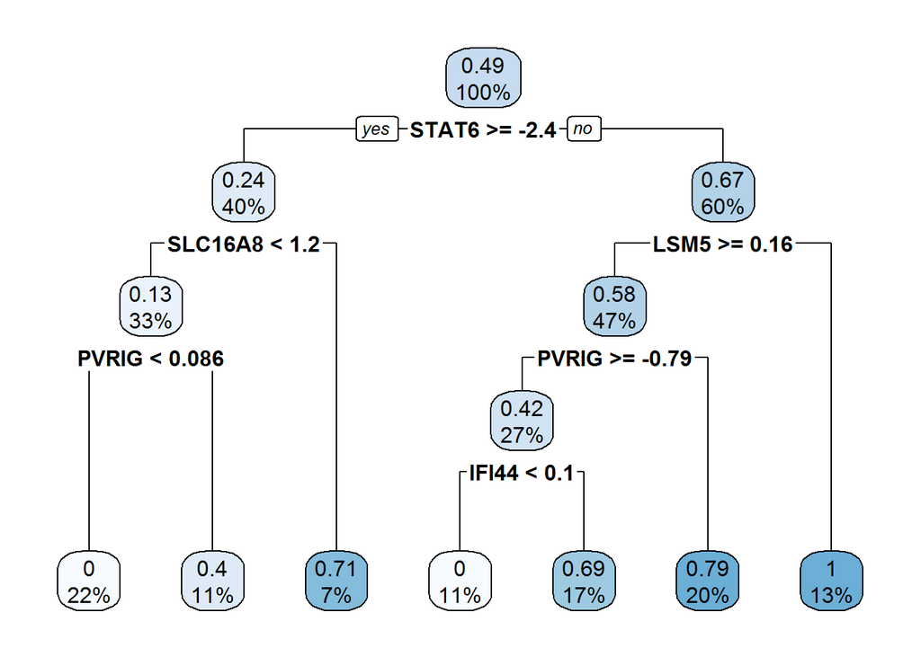

```r
przykldrzewo<-rpart(smierc~.,data=dane[indeksy,-c(1,2)])
rpart.plot(przykldrzewo)
```

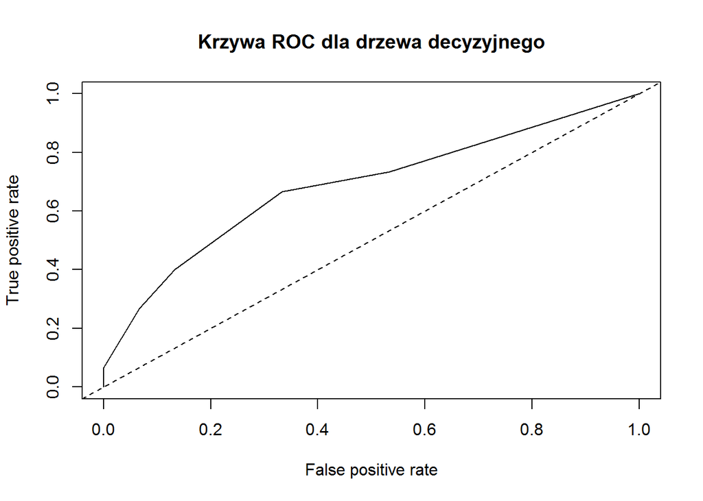

```r
pred<-predict(przykldrzewo,newdata=dane[-indeksy,-2])
MSE.RPART<-mse(pred,dane[-indeksy,"smierc"])

p<-prediction(pred,dane[-indeksy,"smierc"])
plot(performance(p, "tpr", "fpr"),  main = "Krzywa ROC dla drzewa decyzyjnego")
abline(0, 1, lty = 2)
```

```r
ROC[7]<-roc(dane[-indeksy,"smierc"], pred)$auc

#mse dla rpart 1:3
Tk.drzewo <- rbind(c(0,0),c(0,0))
MSEtree<-replicate(100,{
  ind<-unlist(createDataPartition(dane$death1y, times=1, p = 0.75))
  drzewo<-rpart(smierc~.,data=dane[ind,-c(1,2)])
  pred<-predict(drzewo,newdata=dane[-ind,-c(1,2)])
  a<-confusion.matrix(dane[-indeksy,"smierc"],pred,threshold=0.5)
  Tk.drzewo<<-mapply(sum,Tk.drzewo,a)
  mse(pred,dane[-ind,"smierc"])
})

# mse dla rpart cv-fold
MSECVtree <- replicate(10, {
  foldy <- createFolds(dane$smierc,k=10)
  a<-lapply(foldy, function(ind){
    drzewo<-rpart(smierc~.,data=dane[-ind,-c(1,2)])
    pred<-predict(drzewo,newdata=dane[ind,-c(1,2)])
    mse(pred,dane[ind,"smierc"])
  })
}
)
```

# Naive Bayes

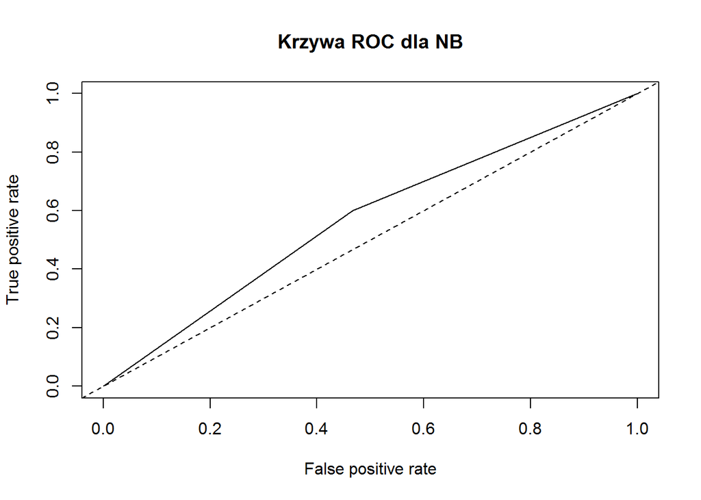

```r
przyklNB<-naiveBayes(as.factor(smierc)~.,data=dane[indeksy,-c(1,2)])
prednb<-as.numeric(as.vector(predict(przyklNB,newdata=dane[-indeksy,-2])))
MSE.NB<-mse(prednb,dane[-indeksy,"smierc"])

p<-prediction(prednb,dane[-indeksy,"smierc"])
plot(performance(p, "tpr", "fpr"),  main = "Krzywa ROC dla NB")
abline(0, 1, lty = 2)
```

```r
ROC[8]<-roc(dane[-indeksy,"smierc"], prednb)$auc

Tk.NB <- rbind(c(0,0),c(0,0))
NB<-replicate(100,{
  indeksy<-c()
  indeksy<-unlist(createDataPartition(dane$death1y, times=1, p = 0.75))
  train<-dane[-indeksy,-2]
  model_NB<-naiveBayes(as.factor(smierc)~.,data=dane[indeksy,-2])
  predy_NB<-predict(model_NB,newdata=dane[-indeksy,-2])
  predi<-as.numeric(as.vector(predy_NB))
  a <- confusion.matrix(dane[-indeksy,"smierc"],predy_NB,threshold=0.5)
  Tk.NB <<- mapply(sum,Tk.NB,a)
  mse(predi,dane[-indeksy,"smierc"])
})

#sto razy łacznie 10x10 mse dla lm z cv-fold
NBCV<-replicate(10,{
  jak<-createFolds(dane$smierc,k=10)
  error<-lapply(jak,function(ind) {
    model_NB<-naiveBayes(as.factor(smierc)~.,data=dane[-ind,-2])
    predy_NB<-predict(model_NB,newdata=dane[ind,-2])
    predi<-as.numeric(as.vector(predy_NB))
    mse(predi,dane[ind,"smierc"])

  })
})
```

## Las losowy

```r
RF<-randomForest(smierc~., data=na.omit(dane[indeksy,-2]), ntree=20)
RF
```

```
##
## Call:
##  randomForest(formula = smierc ~ ., data = na.omit(dane[indeksy,      -2]), ntree = 20)
##                Type of random forest: regression
##                      Number of trees: 20
## No. of variables tried at each split: 8
##
##           Mean of squared residuals: 0.291305
##                     % Var explained: -16.65
```

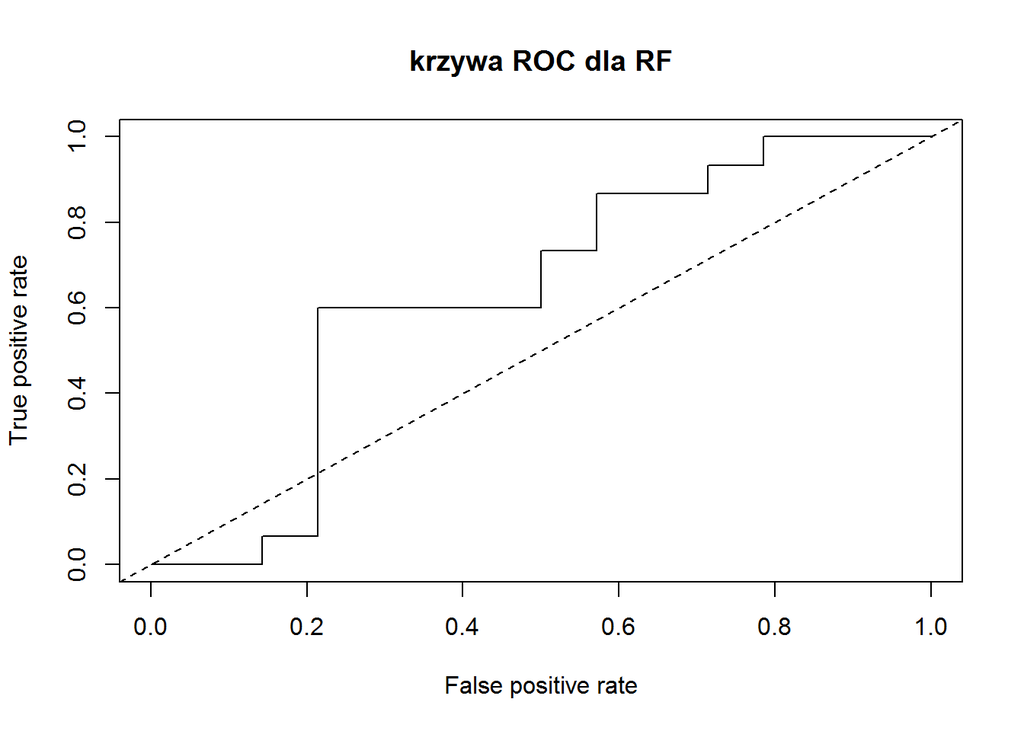

```r
predy.RF<-predict(RF,newdata=dane[-indeksy,-2])
mse.RF<-mse(predy.RF,dane[-indeksy,"smierc"])

p<-prediction(predy.RF,dane[-indeksy,"smierc"])
plot(performance(p, "tpr", "fpr"), main="krzywa ROC dla RF")
abline(0, 1, lty = 2)
```

```r
ROC[9]<-roc(dane[-indeksy,"smierc"], predy.RF)$auc

Tk.RF <- rbind(c(0,0),c(0,0))
RF<-replicate(100,{
  indeksy<-c()
  indeksy<-unlist(createDataPartition(dane$death1y, times=1, p = 0.75))
  model_RF<-randomForest(smierc~., data=na.omit(dane[indeksy,-2]), ntree=20)
  predy_RF<-predict(model_RF,newdata=dane[-indeksy,-2])
  a <- confusion.matrix(dane[-indeksy,"smierc"],predy_RF,threshold=0.5)
  Tk.RF <<- mapply(sum,Tk.RF,a)
  mse(predy_RF,dane[-indeksy,"smierc"])
})

#sto razy łacznie 10x10 mse dla lm z cv-fold
RFCV<-replicate(10,{
  jak<-createFolds(dane$smierc,k=10)
  error<-lapply(jak,function(ind) {
    model_RF<-randomForest(smierc~.,data=na.omit(dane[indeksy,-2]), ntree=20)
    predy_RF<-predict(model_RF,newdata=dane[ind,-2])
    mse(predy_RF,dane[ind,"smierc"])
  })
})
```

# Porównanie użytych metod

Aby porównać użyte modele, przedstawiamy poniżej tabele kontyngencji.

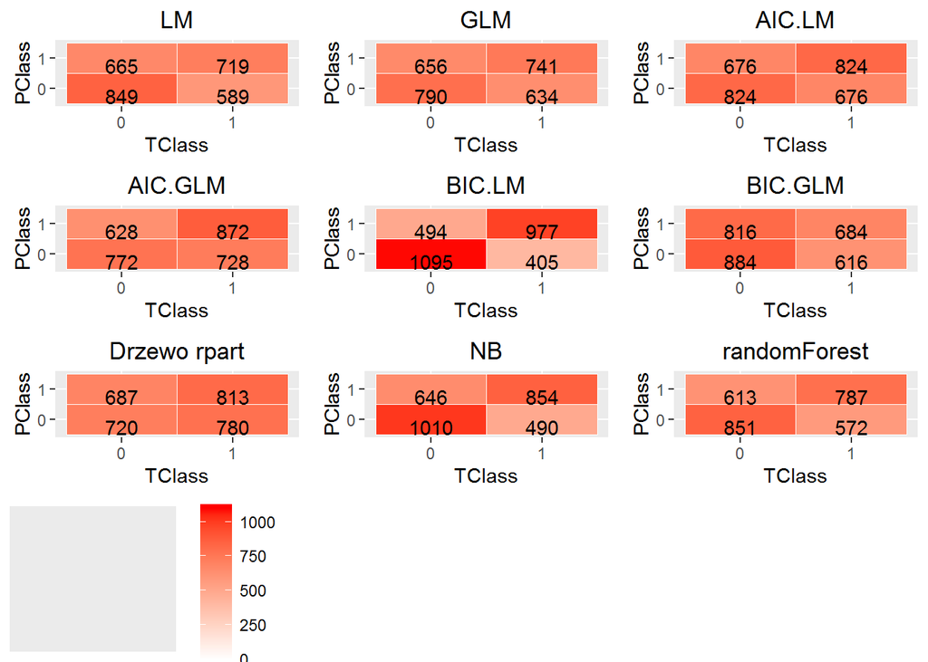

Najlepszym modelem pod względem liczby dobrze zaklasyfikowanych pacjetów do odpowiednich grup okazał się model lm z zastosowanym do niego kryterium BIC.

Poniżej znajduję się porównanie pól pod wykresami krzychych ROC dla poszczególnych metod. Największe pole pod wykresem krzywej ROC ma drzewo.

|  | ROC |
| --- | --- |
| lm | 0.4904762 |
| glm | 0.4904762 |
| lm.AIC | 0.5377778 |
| glm.AIC | 0.5200000 |
| lm.BIC | 0.5200000 |
| glm.BIC | 0.4755556 |
| DRZEWO | 0.6844444 |
| NB | 0.5666667 |
| RF | 0.6333333 |

Poniżej przedstawiamy rozkład błędów średniokwadratowych dla powyższych modeli w przypadku 100 krotnego podziału danych na zbiór uczący sie i testowy z podziałem 1:3 oraz dla 10-fold CV powtórzonej 10 razy.

|  | MSE | MSEcv |
| --- | --- | --- |
| lm | 0.3438736 | 0.3339450 |
| glm | 0.3362019 | 0.3101089 |
| lm.AIC | 0.3027293 | 0.2937315 |
| glm.AIC | 0.3154292 | 0.2944858 |
| lm.BIC | 0.2048663 | 0.2860533 |
| glm.BIC | 0.2862296 | 0.2573994 |
| DRZEWO | 0.3426059 | 0.3405885 |
| NB | 0.3786667 | 0.3855769 |
| RF | 0.2500505 | 0.1006737 |

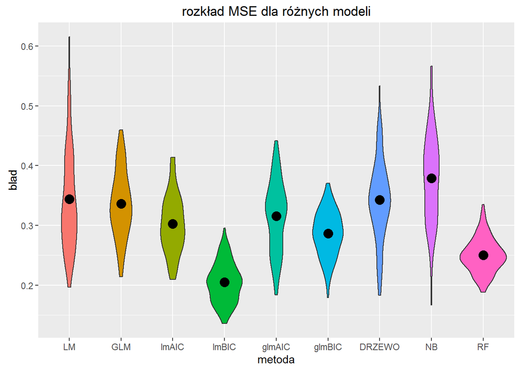

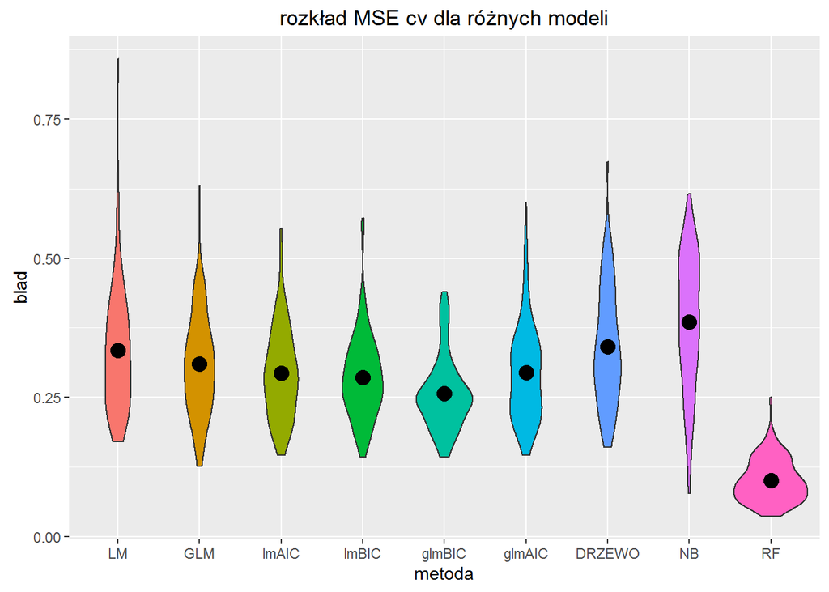

Najmniejszym błedem w przypadku podziału 1:3 charakteryzuje się metoda lm z kryterium BIC, a w przypadku 10-fold CV random forest.